# 5. Structured coalescent inference and ancestral character estimation

Phylodynamics.jl vignettes

Author

Simon D. W. Frost

Published

October 28, 2026

## Overview

Unlike parsimony or time-homogeneous Mk2 trait models, the **Volz (2012) structured coalescent** relates branch coalescent and migration hazards directly to the time-varying epidemiological birth matrix $F(t)$, migration matrix $G(t)$, and deme prevalences $Y(t)$.

`Phylodynamics.jl` provides a complete suite of structured coalescent likelihood and ancestral state reconstruction tools:

- **`DatedTree(tree; demes, sampleTimes, sampleStates)`**: Constructs a dated genealogy with tip state probability annotations.
- **`build_demographic_process(rs, infected, u0, tspan, p)`**: Builds a callable demographic process `dm(theta, x0, t0, t1; res)` directly from a `ModelingToolkit.ReactionSystem`.
- **`colik(bdt, theta, dm; likelihood = :PL2 | :PL1 | :QL)`**: Evaluates the structured coalescent log-likelihood using any of the three lineage-state integration approximations (`solvePikL1`, `solvePikL0`, or `solveQAL`).
- **`ace(bdt, theta, dm)`**: Performs forward-backward Ancestral Character Estimation (`solveQfwd0`) to compute posterior deme probabilities at all internal nodes.
- **`island_coalescent_ml(tree; ...)`**, **`confint_island_coalescent`**, and **`boot_island_coalescent`**: Fits an equilibrium constant-population structured coalescent island model.

## Building a demographic process from a `ReactionSystem`

```julia
using Phylodynamics
using ModelingToolkit
using Catalyst
using CairoMakie
using DataFrames
using StableRNGs
using Printf

bundle = build_zoonosis_reaction_system()
sp = bundle.species
pr = bundle.params
zp2 = model2_params()

u0 = [sp.X1 => zp2.X1_0, sp.Y1 => zp2.Y1_0, sp.X2 => zp2.X2_0, sp.Y2 => zp2.Y2_0]
p  = [pr.nu1 => zp2.nu1, pr.mu1 => zp2.mu1, pr.gamma1 => zp2.gamma1, pr.m1 => zp2.m1,
      pr.beta => zp2.beta, pr.nu2 => zp2.nu2, pr.mu2 => zp2.mu2, pr.gamma2 => zp2.gamma2,
      pr.m2 => zp2.m2, pr.epsilon => zp2.epsilon, pr.phi => zp2.phi, pr.psi => zp2.psi]

dm = build_demographic_process(bundle.rs, [sp.Y1, sp.Y2], u0, (0.0, zp2.t_peak), p)
```

```
(::Phylodynamics.var"#dm#build_demographic_process##0"{Phylodynamics.ModelFGY, Phylodynamics.var"#dm#172#build_demographic_process##1"{Phylodynamics.ModelFGY}}) (generic function with 5 methods)
```

Given a simulated phylogeny `t2`, we wrap it in a `DatedTree` and compare the `:PL2`, `:PL1`, and `:QL` likelihood approximations of `colik`:

```julia
t1 = simulate_coalescent_tree(model1_params(); n1 = 100, n2 = 10, rng = StableRNG(101))
t2 = simulate_coalescent_tree(model2_params(); n1 = 100, n2 = 10, rng = StableRNG(202))
t3 = simulate_coalescent_tree(model3_params(); n1 = 100, n2 = 30, rng = StableRNG(42))

bdt2 = DatedTree(t2; demes = ["Y1", "Y2"], minEdgeLength = 1e-5)
theta_true = Dict("epsilon" => 0.01, "phi" => 4.0, "psi" => 0.0)

DataFrame(
    Approximation = [":PL2 (solvePikL1)", ":PL1 (solvePikL0)", ":QL (solveQAL)"],
    LogLikelihood = [
        colik(bdt2, theta_true, dm; res = 300, timeOfOriginBoundaryCondition = false, likelihood = :PL2),
        colik(bdt2, theta_true, dm; res = 300, timeOfOriginBoundaryCondition = false, likelihood = :PL1),
        colik(bdt2, theta_true, dm; res = 300, timeOfOriginBoundaryCondition = false, likelihood = :QL)
    ]
)
```

3×2 DataFrame

| Row | Approximation String | LogLikelihood Float64 |
| --- | --- | --- |
| 1 | :PL2 (solvePikL1) | -559.339 |
| 2 | :PL1 (solvePikL0) | -508.628 |
| 3 | :QL (solveQAL) | -563.929 |

## Profile likelihoods and hypothesis tests for $\phi$ (human spread) and $\psi$ (reverse zoonosis)

Using `profile_structured_coalescent(t1, t2, t3)`, we compute 1D profile log-likelihood curves over the human-to-human transmission multiplier $\phi$ (testing $H_0: \phi = 0$), the reverse zoonosis multiplier $\psi$ (testing $H_0: \psi = 0$), and the 2D $(\epsilon, \phi)$ surface:

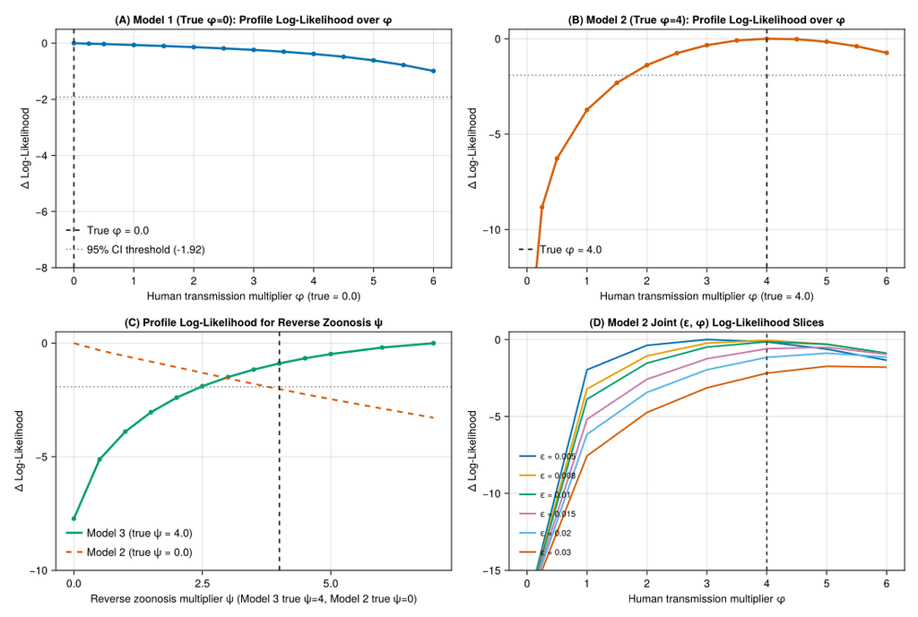

```julia
prof = profile_structured_coalescent(t1, t2, t3; likelihood = :PL2)
fig_prof = plot_fig7_structured_coalescent_profiles(prof; outdir = mktempdir())
fig_prof
```

- On **Model 1** (true $\phi = 0$, Panel A), the profile log-likelihood peaks at the boundary $\hat{\phi} = 0.0$ and decreases monotonically, yielding $\text{LRT}_{21} = 0$.
- On **Model 2** (true $\phi = 4.0, \psi = 0$, Panel B), $\phi = 0$ is rejected by $> 17$ log-likelihood units ($2\Delta\ell = 34.6, p < 10^{-8}$) and the profile peaks at $\hat{\phi} = 4.0$, while the reverse-zoonosis profile (Panel C, dashed orange) peaks at $\hat{\psi} = 0.0$.
- On **Model 3** (true $\phi = 4.0, \psi = 4.0$, Panel C, solid green), the null hypothesis $\psi = 0$ is rejected by $\Delta\ell = -7.74$ ($2\Delta\ell = 15.48, p < 10^{-4}$).

## Forward-backward Ancestral Character Estimation (`ace`)

Calling `ace(bdt, theta, dm)` runs the upward coalescent pass followed by the downward transition matrix pass (`solveQfwd0`) to compute posterior host-state probabilities `bdt.acestates` (`m × (n + Nnode)`) at every internal node of the phylogeny:

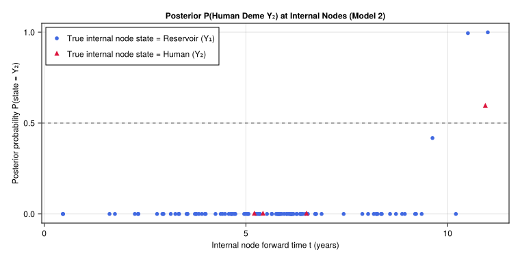

```julia
bdt2_ace = ace(bdt2, theta_true, zoonosis_demographic_process(model2_params());
    res = 300, timeOfOriginBoundaryCondition = false, likelihood = :PL2)

n_tips = bdt2_ace.n
int_nodes = (n_tips + 1):(n_tips + bdt2_ace.Nnode)
node_t_fwd = bdt2_ace.maxSampleTime .- bdt2_ace.heights[int_nodes]
p_human_post = bdt2_ace.acestates[2, int_nodes]
true_int_state = t2.node_state[int_nodes]

fig_ace = Figure(size = (760, 380), fontsize = 12)
ax_ace = Axis(fig_ace[1, 1];
    title = "Posterior P(Human Deme Y₂) at Internal Nodes (Model 2)",
    xlabel = "Internal node forward time t (years)",
    ylabel = "Posterior probability P(state = Y₂)"
)
idx_res = findall(==(1), true_int_state)
idx_hum = findall(==(2), true_int_state)
scatter!(ax_ace, node_t_fwd[idx_res], p_human_post[idx_res];
    color = :royalblue, markersize = 8, label = "True internal node state = Reservoir (Y₁)")
scatter!(ax_ace, node_t_fwd[idx_hum], p_human_post[idx_hum];
    color = :crimson, marker = :utriangle, markersize = 10, label = "True internal node state = Human (Y₂)")
hlines!(ax_ace, [0.5]; color = :gray50, linestyle = :dash)
axislegend(ax_ace; position = :lt, framevisible = true)
fig_ace
```

## Equilibrium island-model inference (`island_coalescent_ml`)

When demographic trajectories are unknown and demes are approximated as constant-size islands with migration rates $\mu_{kl}$ and effective population sizes $N_{e,k}$, `island_coalescent_ml`, `confint_island_coalescent`, and `boot_island_coalescent` fit the equilibrium structured coalescent model:

```julia
fit_island = island_coalescent_ml(t2; maxiters = 100, likelihood = :QL)
println("Converged log-likelihood: ", round(fit_island.loglik, digits = 3))
println("Expected directional jumps matrix: ", round.(fit_island.expected_jumps, digits = 2))
DataFrame(
    Parameter = collect(keys(fit_island.coef)),
    Estimate = round.(collect(values(fit_island.coef)), digits = 4)
)
```

```
Converged log-likelihood: -627.453
Expected directional jumps matrix: [0.0 10.94; 38.56 0.0]
```

4×2 DataFrame

| Row | Parameter String | Estimate Float64 |
| --- | --- | --- |
| 1 | Y | 44.1904 |
| 2 | I->Y | 0.0 |
| 3 | I | 4.2928e5 |
| 4 | Y->I | 0.0722 |

And the internal-node ancestral character table `fit_island.ace` returned by `island_coalescent_ml`:

```julia
first(fit_island.ace, 8)
```

8×2 DataFrame

| Row | I Float64 | Y Float64 |
| --- | --- | --- |
| 1 | 1.0 | 0.0 |
| 2 | 1.0 | 0.0 |
| 3 | 1.0 | 0.0 |
| 4 | 1.0 | 0.0 |
| 5 | 1.0 | 0.0 |
| 6 | 1.0 | 0.0 |
| 7 | 1.0 | 0.0 |
| 8 | 1.0 | 0.0 |